# MAT00058H - Assignment 2

Matthew Knowles - 205006718

08/02/2021

## Setting up

We begin by loading the data in the standard way. Note before continuing I have set the seed to 1234 in the R setup of this RMD document, so that is why it does not appear later on. Now, onto the data…

```r
  beefData <- read.csv("/home/matthew/Documents/University/PDS/Datasets/dry_aged_beef.csv",
                       header = F)
```

## Principal Component Analysis

We now begin performing PCA. The aim is initially to identify any outliers.

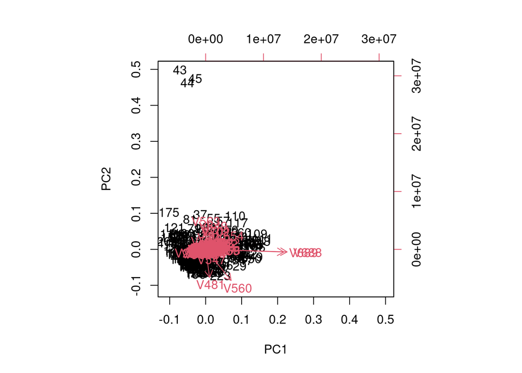

```r
  beefPCA <- prcomp(beefData[,-1])
  biplot(beefPCA)
```

We can very clearly see that V43, V44, V45 are outliers, so we will remove them.

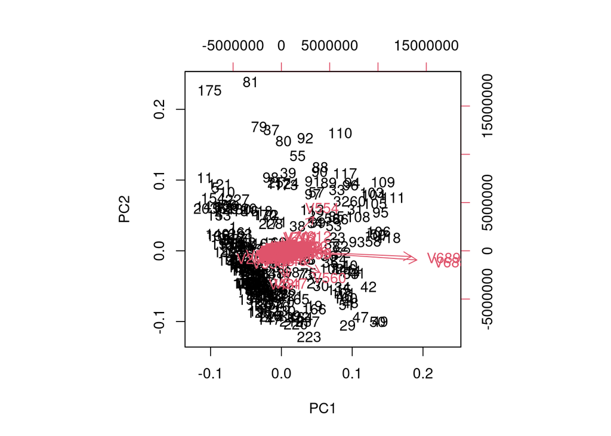

```r
beefData <- beefData[-(43:45),]
beefPCA <- prcomp(beefData[,-1])
biplot(beefPCA)
```

This clearly looks a lot better. Upon looking at it though one could argue that 175 and 81 are outliers, but I am going to leave them in on the reasoning that a) their value in PC1 is very in-line with a large cluster of the samples, and they don’t exist very far outside the main clusters in PC2, whereas the 3 outliers we did remove were very extremely valued in PC2.

## Creating Testing and Training Sets

We can use the *sample()* to generate two sets, one for training and one for testing.

```r
index = sample(1:nrow(beefData), size= round(0.7*nrow(beefData)), replace=FALSE)

trainData = beefData[index,]
testData = beefData[-index,]
```

## Trees

With our training and test data all set up, we can now create a tree.

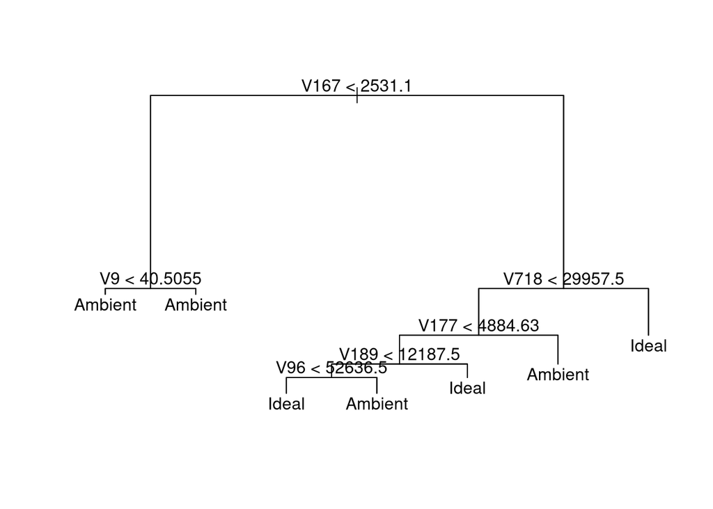

```r
beefData$V1 <- as.factor(beefData$V1) #Data is non-numeric
beefTree <- tree(V1~., data=beefData)
plot(beefTree)
text(beefTree)
```

We can now check the accuracy of the model. First, for the training set:

```r
tree.pred = predict(beefTree, trainData[,-1], type="class")
table(predicted = tree.pred, true= trainData[,1])
```

```
##          true
## predicted Ambient Ideal
##   Ambient      71     1
##   Ideal         0    92
```

From this we can actually calculate the acuracy.

```r
(71+92)/dim(trainData)[1]
```

```
## [1] 0.9939024
```

We can see that this is 99% accurate. Let’s now check for the test set:

```r
tree.pred = predict(beefTree, testData[,-1], type="class")
table(predicted = tree.pred, true= testData[,1])
```

```
##          true
## predicted Ambient Ideal
##   Ambient      44     0
##   Ideal         0    27
```

Again, the accuracy is:

```r
(44+27)/dim(testData)[1]
```

```
## [1] 1
```

So this tells us the test set is perfectly accurate. We now move on to cross-validation. We can run k-fold cross validation on the tree using *cv.tree* as below:

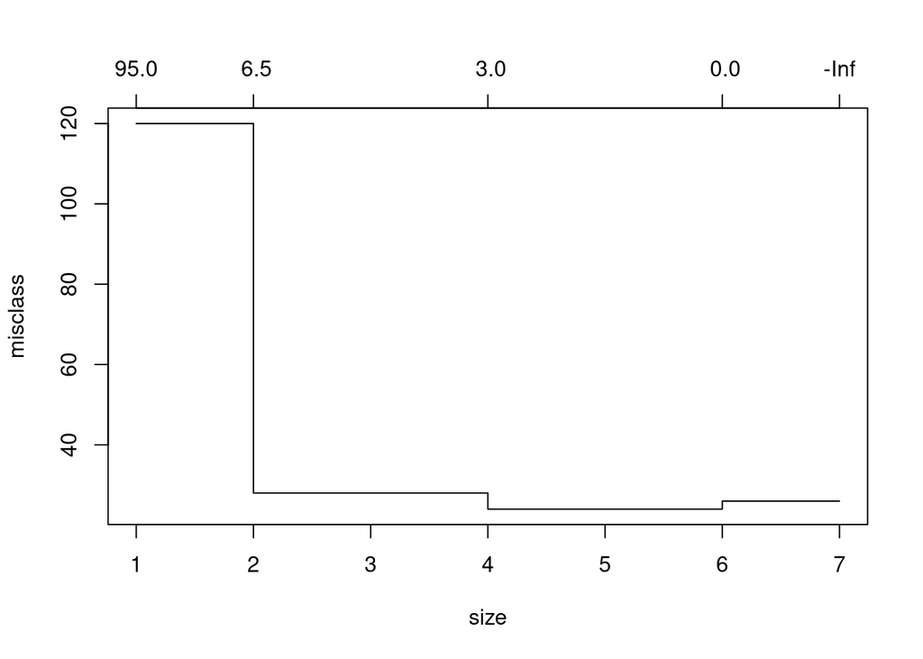

```r
beefCV = cv.tree(beefTree, FUN=prune.misclass)
plot(beefCV)
```

We next run the pruning code, chosing to use *best=4* based on the above CV graph.

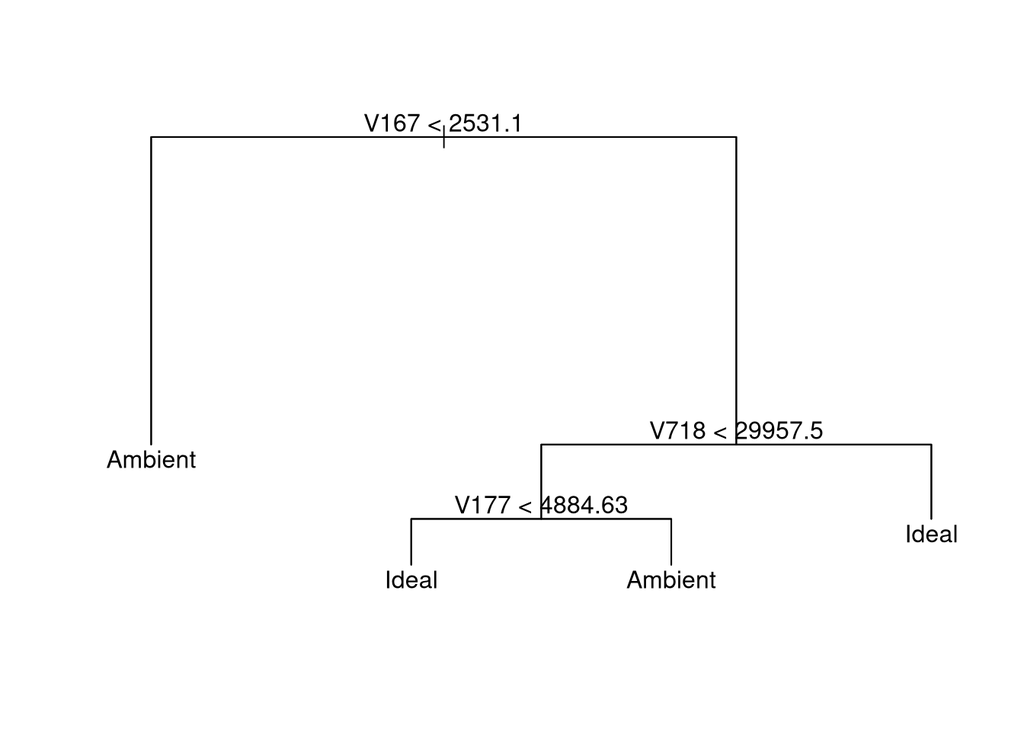

```r
pruneBeef = prune.misclass(beefTree, best=4)
plot(pruneBeef)
text(pruneBeef)
```

Now with our simpler tree, let us retest the accuracy, first for the training set.

```r
tree.pred = predict(pruneBeef, testData[,-1], type="class")
table(predicted = tree.pred, true= testData[,1])
```

```
##          true
## predicted Ambient Ideal
##   Ambient      41     0
##   Ideal         3    27
```

```r
(41+27)/dim(trainData)[1]
```

```
## [1] 0.4146341
```

This is considerably less accurate than last time. What about the test set?

```r
tree.pred = predict(pruneBeef, trainData[,-1], type="class")
table(predicted = tree.pred, true= trainData[,1])
```

```
##          true
## predicted Ambient Ideal
##   Ambient      68     1
##   Ideal         3    92
```

```r
(68+92)/dim(trainData)[1]
```

```
## [1] 0.9756098
```

## Forests

We can now build a random forest classifier. We will use the same training set as last time.

```r
set.seed(1234)
trainData$V1 <- as.factor(trainData$V1)
beefForest = randomForest(V1~., data=trainData, mtry=35, ntree=500)
beefForest
```

```
##
## Call:
##  randomForest(formula = V1 ~ ., data = trainData, mtry = 35, ntree = 500)
##                Type of random forest: classification
##                      Number of trees: 500
## No. of variables tried at each split: 35
##
##         OOB estimate of  error rate: 7.32%
## Confusion matrix:
##         Ambient Ideal class.error
## Ambient      62     9  0.12676056
## Ideal         3    90  0.03225806
```

With this we can read straight from the summary that the *out of bag* error estamate is 7.32% for the training set. When we first trained the model had an accuracy of 99%, so this is a bit worse. But before calling it quits we should see how well it predicts training and test data and make that comparoson.

```r
beefForestPred = predict(beefForest, trainData[,-1], type="class")
table(predicted=beefForestPred, true = trainData[,1])
```

```
##          true
## predicted Ambient Ideal
##   Ambient      71     0
##   Ideal         0    93
```

```r
(71+93)/dim(trainData)[1]
```

```
## [1] 1
```

Which is perfectly accurate, as was the case before. What about the test set though?

```r
beefForestPred = predict(beefForest, testData[,-1], type="class")
table(predicted=beefForestPred, true = testData[,1])
```

```
##          true
## predicted Ambient Ideal
##   Ambient      35     0
##   Ideal         9    27
```

```r
(35+27)/dim(testData)[1]
```

```
## [1] 0.8732394
```

So the random forest has an accuracy of 100% for training data nd 87% for test data.

```r
100*(1-(35+27)/dim(testData)[1])
```

```
## [1] 12.67606
```

## Improving the forest

We tried 500 trees last time and it resulted in over-fitting, what about with 100?

```r
set.seed(1234)
trainData$V1 <- as.factor(trainData$V1)
beefForestN = randomForest(V1~., data=trainData, mtry=35, ntree=100)
beefForestN
```

```
##
## Call:
##  randomForest(formula = V1 ~ ., data = trainData, mtry = 35, ntree = 100)
##                Type of random forest: classification
##                      Number of trees: 100
## No. of variables tried at each split: 35
##
##         OOB estimate of  error rate: 8.54%
## Confusion matrix:
##         Ambient Ideal class.error
## Ambient      61    10  0.14084507
## Ideal         4    89  0.04301075
```

We can see the OOB error rate is slightly higher, but what about accuracy for test and training? We repeat the process as before:

```r
beefForestPredN = predict(beefForestN, trainData[,-1], type="class")
table(predicted=beefForestPredN, true = trainData[,1])
```

```
##          true
## predicted Ambient Ideal
##   Ambient      71     0
##   Ideal         0    93
```

```r
(71+93)/dim(trainData)[1]
```

```
## [1] 1
```

So there is no difference for training.

```r
beefForestPred = predict(beefForest, testData[,-1], type="class")
table(predicted=beefForestPred, true = testData[,1])
```

```
##          true
## predicted Ambient Ideal
##   Ambient      35     0
##   Ideal         9    27
```

```r
(35+27)/dim(testData)[1]
```

```
## [1] 0.8732394
```